# Using AeroSampleR to model aerosol sampling efficiency

### 5) Generate reports with `report_basic`, `report_plots` and `report_cum_plots`

The `report_basic` function provides total system efficiency for either all of the logarithmically distributed particles or all of the discrete particle sizes.

The `report_plots` function shows individual element efficiency. The `report_cum_plots` function shows cumulative efficiency through the system. This plot takes efficiency data from the rows of the data frame. It therefore only works for individually selected particle sizes.

We’ll show the parameter set first, so that the output message on the basic report, regarding units, makes sense.

```r
params[, 7] <- formatC(params[, 7], digits = 2, format = "e")
params[, 8] <- formatC(params[, 8], digits = 2, format = "e")
params[, 11] <- formatC(params[, 11], digits = 2, format = "e")
params[, 3] <- formatC(params[, 3], digits = 4)
params[, 10] <- formatC(params[, 10], digits = 4)
ft <- flextable(params)
ft <- set_caption(ft, "system parameters")
ft
```

system parameters

| D_tube | Q_lpm | velocity_air | T_K | P_kPa | density_air | viscosity_air | mfp | density_par | Re | k |
| --- | --- | --- | --- | --- | --- | --- | --- | --- | --- | --- |
| 0.0221 | 56.6 | 2.459 | 298.15 | 101.325 | 1.183907 | 1.84e-05 | 6.67e-02 | 1,000 | 3502 | 1.38e-23 |

```r
ft <- flextable(report_basic(df, params, "discrete"))
```

```
#> System Parameters
#> All values in MKS units, except noted
#> Notes: D_tube is in m.
#> Q_lpm is system flow in liters per minute.
#> velocity_air is the derived air flow velocity in meters per second.T_K is system temperature in Kelvin.
#> P_kPa is system pressure in kiloPascals.
#> Re is the system Reynolds number, a measure of turbulence.
```

```r
ft <- colformat_double(ft, digits = 3)
ft <- set_caption(ft, "results for discrete particle diameters")
ft
```

results for discrete particle diameters

| D_p | sys_eff |
| --- | --- |
| 1.000 | 0.999 |
| 5.000 | 0.962 |
| 10.000 | 0.848 |

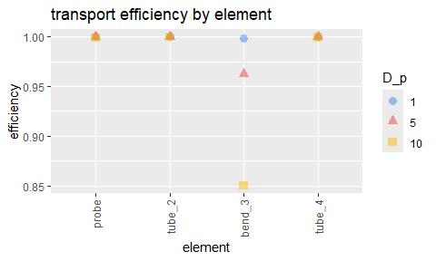

```r
report_plots(df, "discrete")
```

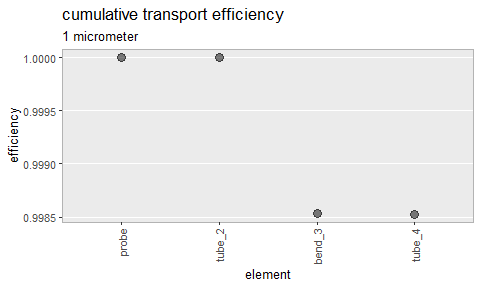

```r
report_cum_plots(df, 1)
```

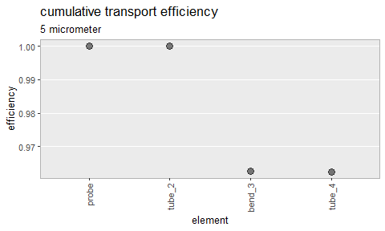

```r
report_cum_plots(df, 5)
```

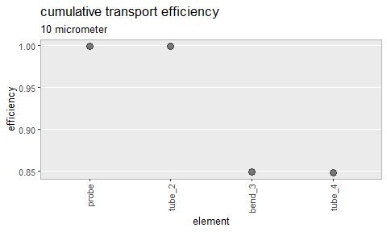

```r
report_cum_plots(df, 10)
```

```r
ft <- flextable(report_basic(df, params, "log"))
```

```
#> System Parameters
#> All values in MKS units, except noted
#> Notes: D_tube is in m.
#> Q_lpm is system flow in liters per minute.
#> velocity_air is the derived air flow velocity in meters per second.T_K is system temperature in Kelvin.
#> P_kPa is system pressure in kiloPascals.
#> Re is the system Reynolds number, a measure of turbulence.
```

```r
ft <- colformat_double(ft, digits = 3)
ft <- set_caption(ft, "results for log distribution of particle diameters")
ft
```

results for log distribution of particle diameters

| activity.fraction.sampled |
| --- |
| 0.170 |

### 6) Optional extra reports for the logarithmically distributed particle set

The `report_log_mass` function provides details on every particle size.

Since there are 1000 data points, the full ouptput is probably not suitable for a typical report. The report provides the following columns of output:

- microns = the particle size in micrometers (microns is shorter, but is considered superseded by micrometers)
- probs = relative probability of a particle being in this size bin
- bin_eff = the overall system efficiency for a particle of this size
- amb_mass = the probability of the particle multiplied by the mass of a spherical particle with the size given and density of 1 g per ml. This is the relative mass of this particle size in the ambient air being sampled.
- sampled_mass = the relative mass that made it through the sampling system with this particle size
- bin_frac_lost = ambient mass in this bin minus the sampled mass in the bin, divided by the ambient mass
- total_frac_lost = ambient mass in this bin minus the sampled mass in the bin, divided by the sum of the ambient mass

A random selection of ten rows of the 1000 rows are provided below:

```r
df_log <- report_log_mass(df)[sort(sample(1:1000, 10)), ]
# need to make format changes so that flextable will show scientific notation
df_log[, 1] <- formatC(df_log[, 1], digits = 4)
df_log[, 2] <- formatC(df_log[, 2], digits = 2, format = "e")
df_log[, 3] <- formatC(df_log[, 3], digits = 2, format = "e")
df_log[, 4] <- formatC(df_log[, 4], digits = 2, format = "e")
df_log[, 5] <- formatC(df_log[, 5], digits = 2, format = "e")
df_log[, 6] <- formatC(df_log[, 6], digits = 2, format = "e")
df_log[, 7] <- formatC(df_log[, 7], digits = 2, format = "e")
ft <- flextable(df_log)
ft <- colformat_double(ft, digits = 3)
ft <- set_caption(ft, "results for random sample of 1000 particle diameters from the log set")
ft
```

results for random sample of 1000 particle diameters from the log set

| D_p | dens | bin_eff | amb_mass | sampled_mass | bin_frac_lost | total_frac_lost |
| --- | --- | --- | --- | --- | --- | --- |
| 0.001989 | 3.05e-14 | 9.97e-01 | 3.04e-27 | 3.03e-27 | 3.41e-03 | 5.19e-33 |
| 0.004735 | 2.67e-11 | 9.99e-01 | 8.54e-23 | 8.54e-23 | 1.08e-03 | 4.64e-29 |
| 0.008617 | 1.70e-09 | 1.00e+00 | 5.96e-20 | 5.96e-20 | 4.94e-04 | 1.47e-26 |
| 0.011 | 8.19e-09 | 1.00e+00 | 7.63e-19 | 7.63e-19 | 3.60e-04 | 1.38e-25 |
| 0.3713 | 2.09e-02 | 1.00e+00 | 2.53e-06 | 2.53e-06 | 2.46e-04 | 3.12e-13 |
| 0.6279 | 5.34e-02 | 9.99e-01 | 5.28e-05 | 5.27e-05 | 6.16e-04 | 1.63e-11 |
| 0.6513 | 5.63e-02 | 9.99e-01 | 6.44e-05 | 6.44e-05 | 6.58e-04 | 2.13e-11 |
| 1.648 | 1.27e-01 | 9.96e-01 | 5.96e-03 | 5.93e-03 | 3.93e-03 | 1.17e-08 |
| 3.738 | 1.11e-01 | 9.79e-01 | 1.37e-01 | 1.35e-01 | 2.07e-02 | 1.42e-06 |
| 23.08 | 4.68e-03 | 3.65e-01 | 8.45e+00 | 3.09e+00 | 6.35e-01 | 2.69e-03 |

The particle mass modeled in the ambient air and sampled through the air sampling system is shown with the function `report_plots`.

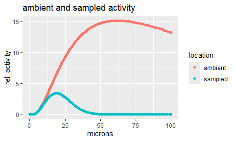

```r
report_plots(df, "log")
```